# Using Code link & code fold for instructional purposes

Author

Alberto

# 1 Quarto

## 1.1 Eliminating warning when loading libraries

Use the option `#| warning: false`*.* The option `#| include: false` overrides *`code-link: true`* function

```r
library(tidyverse)
```

The download arrow Code displays the r functions. The code displays links the r functions to their corresponding websites. See its application in Figure 1 the scatterplot displaying mile displacement by mpg

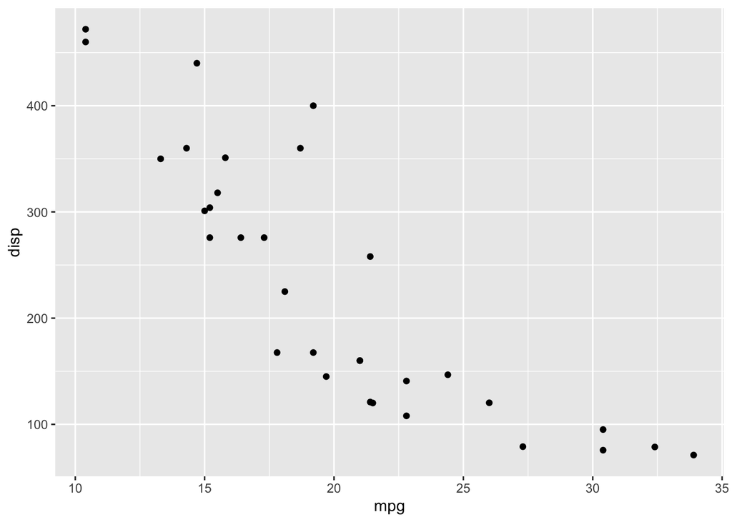

Figure 1: displacement-by-mpg

```r
mtcars %>%
  ggplot(aes(x = mpg, y = disp)) +
    geom_point()
```

# 2 **Quarto Computations**

This dataset contains a subset of the fuel economy data from the EPA. Specifically, we use the `mpg` dataset from the **ggplot2** package.

The Figure 2 visualization below shows a positive, strong, and linear relationship between the city and highway mileage of 234 cars. Additionally, mileage is higher for cars with fewer cylinders.

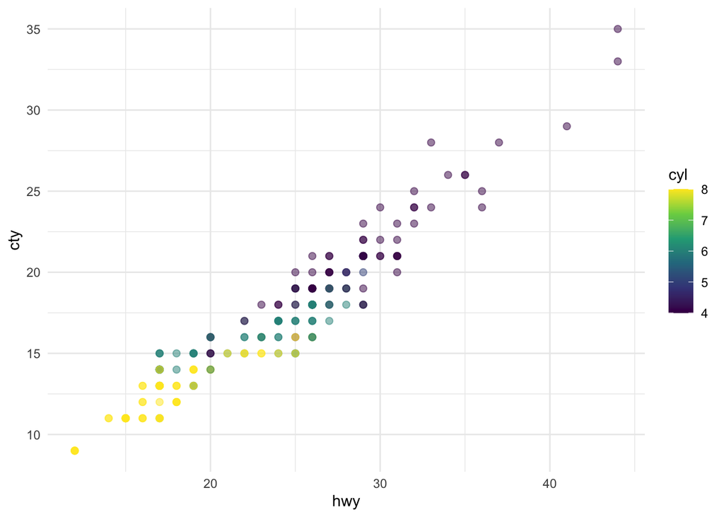

```r
ggplot(mpg, aes(x = hwy, y = cty, color = cyl)) +
  geom_point(alpha = 0.5, size = 2) +
  scale_color_viridis_c() +
  theme_minimal()
```

# 3 Using Penguins example

For this analysis we will use penguins data set from the [palmerpinguins](https://CRAN.R-project.org/package=palmerpenguins) package.

```r
library(tidyverse)
library(ggthemes)
library(palmerpenguins)
library(gt)
library(downlit)
```

Describing data base corresponding to 344 across 8 characteritics such as species, island, gender, year of observation and body characteristics.

```r
glimpse(penguins)
```

```
Rows: 344
Columns: 8
$ species           <fct> Adelie, Adelie, Adelie, Adelie, Adelie, Adelie, Adel…
$ island            <fct> Torgersen, Torgersen, Torgersen, Torgersen, Torgerse…
$ bill_length_mm    <dbl> 39.1, 39.5, 40.3, NA, 36.7, 39.3, 38.9, 39.2, 34.1, …
$ bill_depth_mm     <dbl> 18.7, 17.4, 18.0, NA, 19.3, 20.6, 17.8, 19.6, 18.1, …
$ flipper_length_mm <int> 181, 186, 195, NA, 193, 190, 181, 195, 193, 190, 186…
$ body_mass_g       <int> 3750, 3800, 3250, NA, 3450, 3650, 3625, 4675, 3475, …
$ sex               <fct> male, female, female, NA, female, male, female, male…
$ year              <int> 2007, 2007, 2007, 2007, 2007, 2007, 2007, 2007, 2007…
```

## 3.1 Species

Figure 3 is a scatter plot of species of penguins

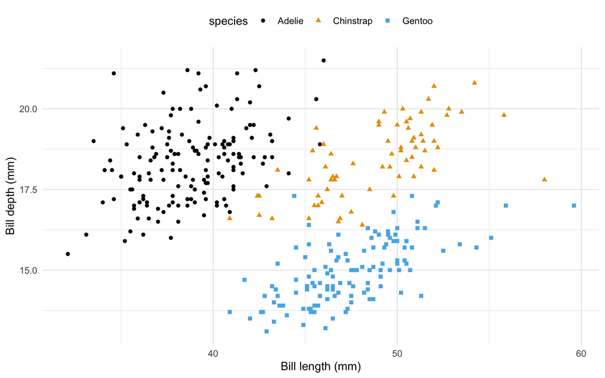

Figure 3: A scatterplot of penguins’ bill depth and length, colored by species of penguins.

```r
ggplot(data = penguins,
       aes(x= bill_length_mm,
           y = bill_depth_mm,
           color = species,
           shape = species)) +
  geom_point() +
  scale_color_colorblind()+
  theme_minimal()+
  theme(legend.position ="top")+
  labs(x = "Bill length (mm)", y = "Bill depth (mm)")
```

## 3.2 Penguins

Table 1 shows the fist 10 penguins from the dataset with annotations

```r
library(tidyverse)
library(palmerpenguins)
library(dplyr)

penguins %>%
  slice_head(n=10) %>%
  select(species, island, bill_length_mm,bill_depth_mm) %>%
  gt()
```

Table 1: First 10 pinquins.

| species | island | bill_length_mm | bill_depth_mm |
| --- | --- | --- | --- |
| Adelie | Torgersen | 39.1 | 18.7 |
| Adelie | Torgersen | 39.5 | 17.4 |
| Adelie | Torgersen | 40.3 | 18.0 |
| Adelie | Torgersen | NA | NA |
| Adelie | Torgersen | 36.7 | 19.3 |
| Adelie | Torgersen | 39.3 | 20.6 |
| Adelie | Torgersen | 38.9 | 17.8 |
| Adelie | Torgersen | 39.2 | 19.6 |
| Adelie | Torgersen | 34.1 | 18.1 |
| Adelie | Torgersen | 42.0 | 20.2 |

1. Start with the penguins data frame
2. Then slice the top ten rows
3. Select some variable and make a table with gt()